# SymplecticFTRL22

```python
%load_ext autoreload

%autoreload 2
```

```
The autoreload extension is already loaded. To reload it, use:
  %reload_ext autoreload
```

```python
import numpy as np
import matplotlib.pyplot as plt
from scipy.integrate import odeint
import itertools
import sympy as sp

import gamelab.finitegames as nfg
import symplecticFTRL
import choice
import aspera.utils
```

```python
primal_letter = 'x'
dual_letter = 'y'
quot_letter = 'z'
```

## Utils

```python
# switch between coords and points
#def coords_points(L):

	#https://stackoverflow.com/questions/2921847/what-does-the-star-operator-mean-in-a-function-call
#	def make(*values):
#		return values

#	return make(*zip(*L))
```

```python
flatten = nfg.Utils.flatten
coords_points = aspera.utils.coords_points
```

# Symplectic FTRL on mixed extension of $[2 \times 2]$ normal form games

```python
skeleton = [2, 2]
```

```python
BARE = nfg.NFG_bare(skeleton, "numeric", primal_letter)
```

```python
help(nfg.NFG)
```

```
Help on class NFG in module gamelab.finitegames:

class NFG(NFG_bare)
 |  NFG(skeleton, strat_format, primal_letter, dual_letter, name, payoff_tensors)
 |  docstring for ClassName
 |  Method resolution order:
 |      NFG
 |      NFG_bare
 |      Skeleton
 |      builtins.object
 |  Methods defined here:
 |  __init__(self, skeleton, strat_format, primal_letter, dual_letter, name, payoff_tensors)
 |      Initialize self.  See help(type(self)) for accurate signature.
 |  make_clean_payfield(self)
 |  ----------------------------------------------------------------------
 |  Methods inherited from NFG_bare:
 |  make_packed(self, letter, skeleton)
 |      Returns packed list of multi-indexed letter, e.g. [[x0_0, x0_1], [x1_0, x1_1]]
 |  make_strat(self, xi, skeleton)
 |      - Given names for strats_play, say [x_0, x_1, x_2] or [x, y, z], generates corresponding strat
 |      - Initialize an empty list to store the symbolic entries
 |      - Returns list of sympy matrices to allow for operations
 |  make_strat_play(self)
 |      Returns (x_0, ... x_(N-1)), one for each player's mixed strategy
 |      Wheter x_index or letter is used depends on self.strat_format
 |  make_vars(self, letter, skeleton)
 |      Returns flat list of multi-indexed letter, e.g. [x0_0, x0_1, x1_0, x1_1]
 |  make_vars_play(self, letter, skeleton)
 |      Returns list of player-indexed letter, e.g. [x_0, x_1]
 |  on_simplex(self, expr)
 |  ----------------------------------------------------------------------
 |  Data descriptors inherited from Skeleton:
 |  __dict__
 |      dictionary for instance variables
 |  __weakref__
 |      list of weak references to the object
```

```python
BARE.strat
```

```
[Matrix([
 [x0_0],
 [x0_1]]),
 Matrix([
 [x1_0],
 [x1_1]])]
```

```python
BARE.primal_vars
```

```
[x0_0, x0_1, x1_0, x1_1]
```

```python
BARE.make_vars('y', skeleton)
```

```
[y0_0, y0_1, y1_0, y1_1]
```

```python
BARE.strat_play
```

```
(x0, x1)
```

## Games

```python
# Matching pennies
payoff = [3, -3, -3, 3, -3, 3, 3, -3]
MP = nfg.NFG(skeleton = skeleton , strat_format = 'numeric', primal_letter = primal_letter, dual_letter = dual_letter, name = 'Matching Pennies', payoff_tensors =  nfg.Utils.u_flat_to_tensor(payoff, skeleton))
```

```python
MP.payfield
```

```
[[3*x1_0 - 3*x1_1, -3*x1_0 + 3*x1_1], [-3*x0_0 + 3*x0_1, 3*x0_0 - 3*x0_1]]
```

```python
MP.quotpayfield
```

```
[array([0, -6*x1_0 + 6*x1_1], dtype=object),
 array([0, 6*x0_0 - 6*x0_1], dtype=object)]
```

```python
MP.map_payfield.present()
```

```
V: X0 x X1(4) --> TY0 x TY1(4)
 (x0_0, x0_1, x1_0, x1_1) --> (y'0_0, y'0_1, y'1_0, y'1_1) = [3*x1_0 - 3*x1_1, -3*x1_0 + 3*x1_1, -3*x0_0 + 3*x0_1, 3*x0_0 - 3*x0_1]
```

```python
MP.map_quotpayfield.present()
```

```
v: X0 x X1(4) --> TZ0 x TZ1(4)
 (x0_0, x0_1, x1_0, x1_1) --> (z'0_0, z'0_1, z'1_0, z'1_1) = [0, -6*x1_0 + 6*x1_1, 0, 6*x0_0 - 6*x0_1]
```

```python
MP.map_eff_quotpayfield.present()
```

```
v: X0 x X1(2) --> TZ0 x TZ1(2)
 (x0_1, x1_1) --> (z'0_1, z'1_1) = [12*x1_1 - 6, 6 - 12*x0_1]
```

```python
# generalized harmonic
payoff = [-1, -4, -3, -1, 1, 2, 2, -2]
GH = nfg.NFG(skeleton = skeleton , strat_format = 'numeric', primal_letter = primal_letter, dual_letter = dual_letter, name = 'Generalized Harmonic', payoff_tensors =  nfg.Utils.u_flat_to_tensor(payoff, skeleton))

# prisoner's dilemma
payoff = [2, 0, 3, 1, 2, 3, 0, 1]
PD = nfg.NFG(skeleton = skeleton , strat_format = 'numeric', primal_letter = primal_letter, dual_letter = dual_letter, name = 'Prisoners Dilemma', payoff_tensors =  nfg.Utils.u_flat_to_tensor(payoff, skeleton))

# split or steal
payoff = [5, 0, 10, 0, 5, 10, 0, 0]
SS = nfg.NFG(skeleton = skeleton , strat_format = 'numeric', primal_letter = primal_letter, dual_letter = dual_letter, name = 'Split or Steal', payoff_tensors =  nfg.Utils.u_flat_to_tensor(payoff, skeleton))

# battle of sexes
payoff = [3, 0, 0, 2, 2, 0, 0, 3]
BS = nfg.NFG(skeleton = skeleton , strat_format = 'numeric', primal_letter = primal_letter, dual_letter = dual_letter, name = 'Battle of the Sexes', payoff_tensors =  nfg.Utils.u_flat_to_tensor(payoff, skeleton))

# chicken
payoff = [-5, 2, 1, 0, -5, 1, 2, 0]
CH = nfg.NFG(skeleton = skeleton , strat_format = 'numeric', primal_letter = primal_letter, dual_letter = dual_letter, name = 'Chicken', payoff_tensors =  nfg.Utils.u_flat_to_tensor(payoff, skeleton))

# coordination
payoff = [5, 1, 1, 4, 5, 1, 1, 4]
CO = nfg.NFG(skeleton = skeleton , strat_format = 'numeric', primal_letter = primal_letter, dual_letter = dual_letter, name = 'Coordination', payoff_tensors =  nfg.Utils.u_flat_to_tensor(payoff, skeleton))

# anti-coordination
payoff = [1, 5, 4, 1, 1, 4, 5, 1]
ACO = nfg.NFG(skeleton = skeleton , strat_format = 'numeric', primal_letter = primal_letter, dual_letter = dual_letter, name = 'Anti-Coordination', payoff_tensors =  nfg.Utils.u_flat_to_tensor(payoff, skeleton))

# cyclic
payoff = [5, 1, 1, 4, -5, 1, 1, -4]
CY = nfg.NFG(skeleton = skeleton , strat_format = 'numeric', primal_letter = primal_letter, dual_letter = dual_letter, name = 'Cyclic', payoff_tensors =  nfg.Utils.u_flat_to_tensor(payoff, skeleton))
```

```python
#GAMES = [MP, GH, PD, SS, BS, CH, CO, ACO, CY]
GAMES = [MP, GH, PD, CY]
```

## Vars

```python
primal_vars = BARE.primal_vars
primal_vars
```

```
[x0_0, x0_1, x1_0, x1_1]
```

```python
dual_vars = BARE.make_vars(dual_letter, skeleton)
dual_vars
```

```
[y0_0, y0_1, y1_0, y1_1]
```

```python
quot_vars = BARE.make_vars(quot_letter, skeleton)
quot_vars
```

```
[z0_0, z0_1, z1_0, z1_1]
```

```python
BARE.make_vars_play(dual_letter, skeleton)
```

```
(y0, y1)
```

```python
BARE.make_packed(dual_letter, skeleton)
```

```
[(y0_0, y0_1), (y1_0, y1_1)]
```

```python
# LOGIT CHOICE
#sym_choice = [
#    sp.exp(dual_vars[0]) / ( sp.exp(dual_vars[0]) +  sp.exp(dual_vars[1])),
#    sp.exp(dual_vars[1]) / ( sp.exp(dual_vars[0]) +  sp.exp(dual_vars[1])),
#    sp.exp(dual_vars[2]) / ( sp.exp(dual_vars[2]) +  sp.exp(dual_vars[3])),
#    sp.exp(dual_vars[3]) / ( sp.exp(dual_vars[2]) +  sp.exp(dual_vars[3])),
#]
```

```python
logit = choice.MultiLogit(primal_letter, dual_letter, skeleton)
logit.Q.ex
```

$\displaystyle \left[\begin{matrix}\frac{e^{y_{0 0}}}{e^{y_{0 0}} + e^{y_{0 1}}}\\\frac{e^{y_{0 1}}}{e^{y_{0 0}} + e^{y_{0 1}}}\\\frac{e^{y_{1 0}}}{e^{y_{1 0}} + e^{y_{1 1}}}\\\frac{e^{y_{1 1}}}{e^{y_{1 0}} + e^{y_{1 1}}}\end{matrix}\right]$

# Z quotient

```python
quotlogit = choice.QuotientMultiLogit(primal_letter, dual_letter, skeleton, quot_letter)
quotlogit.Q.ex
```

$\displaystyle \left[\begin{matrix}\frac{1}{e^{z_{0 1}} + 1}\\\frac{e^{z_{0 1}}}{e^{z_{0 1}} + 1}\\\frac{1}{e^{z_{1 1}} + 1}\\\frac{e^{z_{1 1}}}{e^{z_{1 1}} + 1}\end{matrix}\right]$

```python
quotlogit.eff_Q.ex
```

$\displaystyle \left[\begin{matrix}\frac{e^{z_{0 1}}}{e^{z_{0 1}} + 1}\\\frac{e^{z_{1 1}}}{e^{z_{1 1}} + 1}\end{matrix}\right]$

### Access primal and dual spaces either by primal space and dual space of MultiLogit instance, or domain and codomain of Map instance

```python
logit.primal_space.present()
```

```
X0 x X1 4 (x0_0, x0_1, x1_0, x1_1)
```

```python
logit.Q.codomain.present()
```

```
X0 x X1 4 (x0_0, x0_1, x1_0, x1_1)
```

```python
logit.dual_space.present()
```

```
Y0 x Y1 4 (y0_0, y0_1, y1_0, y1_1)
```

```python
logit.Q.domain.present()
```

```
Y0 x Y1 4 (y0_0, y0_1, y1_0, y1_1)
```

## Symplectic FTRL

```python
SFTRL_GAMES = [ symplecticFTRL.SFTRL(game.map_payfield, logit.Q, primal_vars, dual_vars, game.name) for game in GAMES ]
```

```python
SFTRL_GAMES[0].choice( 1, 2, 3, 4 )
```

```
[0.2689414213699951,
 0.7310585786300049,
 0.2689414213699951,
 0.7310585786300048]
```

```python
SFTRL_GAMES[0].payfield(1, 2, 3, 4)
```

```
[-3, 3, 3, -3]
```

```python
SFTRL_GAMES[0].dVQ_VQ(1, 2, 3, 4)
```

```
[-6.541757832452285, 6.541757832452285, -6.541757832452284, 6.541757832452284]
```

## Z FTRL

```python
ZSFTRL_GAMES = [ symplecticFTRL.ZSFTRL(game.map_quotpayfield, quotlogit.Q, primal_vars, quot_vars, game.name) for game in GAMES ]
```

```python
test = ZSFTRL_GAMES[0]
```

```python
test.map_VQ.present()
```

```
v(q_0 x q_1): Z0 x Z1(4) --> TZ0 x TZ1(4)
 (z0_0, z0_1, z1_0, z1_1) --> (z'0_0, z'0_1, z'1_0, z'1_1) = [0, 6*tanh(z1_1/2), 0, -6*tanh(z0_1/2)]
```

```python
test.sym_JQ
```

$\displaystyle \left[\begin{matrix}0 & - \frac{e^{z_{0 1}}}{\left(e^{z_{0 1}} + 1\right)^{2}} & 0 & 0\\0 & \frac{e^{z_{0 1}}}{e^{z_{0 1}} + 1} - \frac{e^{2 z_{0 1}}}{\left(e^{z_{0 1}} + 1\right)^{2}} & 0 & 0\\0 & 0 & 0 & - \frac{e^{z_{1 1}}}{\left(e^{z_{1 1}} + 1\right)^{2}}\\0 & 0 & 0 & \frac{e^{z_{1 1}}}{e^{z_{1 1}} + 1} - \frac{e^{2 z_{1 1}}}{\left(e^{z_{1 1}} + 1\right)^{2}}\end{matrix}\right]$

```python
ZSFTRL_GAMES[0].VQ(1, 2, 3, 4)
```

```
[0, 5.784165480454901, 0, -4.569564935734589]
```

## Effective Z SFTRL

```python
MP.map_eff_quotpayfield.present()
```

```
v: X0 x X1(2) --> TZ0 x TZ1(2)
 (x0_1, x1_1) --> (z'0_1, z'1_1) = [12*x1_1 - 6, 6 - 12*x0_1]
```

```python
quotlogit.eff_Q.present()
```

```
q_0 x q_1: Z0 x Z1(2) --> X0 x X1(2)
 (z0_1, z1_1) --> (x0_1, x1_1) = [exp(z0_1)/(exp(z0_1) + 1), exp(z1_1)/(exp(z1_1) + 1)]
```

```python
quotlogit.eff_Q.domain.vars
```

```
(z0_1, z1_1)
```

```python
quotlogit.eff_Q.codomain.vars
```

```
(x0_1, x1_1)
```

```python
eff_ZSFTRL_GAMES = [ symplecticFTRL.ZSFTRL(game.map_eff_quotpayfield, quotlogit.eff_Q, quotlogit.eff_Q.codomain.vars, quotlogit.eff_Q.domain.vars, game.name) for game in GAMES ]
```

```python
test = eff_ZSFTRL_GAMES[0]
```

```python
test
```

```
<symplecticFTRL.ZSFTRL at 0x1662f8dd0>
```

```python
test.map_VQ.present()
```

```
v(q_0 x q_1): Z0 x Z1(2) --> TZ0 x TZ1(2)
 (z0_1, z1_1) --> (z'0_1, z'1_1) = [6*tanh(z1_1/2), -6*tanh(z0_1/2)]
```

```python
test.sym_JQ
```

$\displaystyle \left[\begin{matrix}\frac{e^{z_{0 1}}}{e^{z_{0 1}} + 1} - \frac{e^{2 z_{0 1}}}{\left(e^{z_{0 1}} + 1\right)^{2}} & 0\\0 & \frac{e^{z_{1 1}}}{e^{z_{1 1}} + 1} - \frac{e^{2 z_{1 1}}}{\left(e^{z_{1 1}} + 1\right)^{2}}\end{matrix}\right]$

```python
test.sym_JQ.inv()
```

$\displaystyle \left[\begin{matrix}\frac{e^{3 z_{0 1}} + 3 e^{2 z_{0 1}} + 3 e^{z_{0 1}} + 1}{e^{2 z_{0 1}} + e^{z_{0 1}}} & 0\\0 & \frac{e^{3 z_{1 1}} + 3 e^{2 z_{1 1}} + 3 e^{z_{1 1}} + 1}{e^{2 z_{1 1}} + e^{z_{1 1}}}\end{matrix}\right]$

```python
test.sym_symplectic_vfield
```

$\displaystyle \left[\begin{matrix}\frac{36 \left(\left(\cosh{\left(z_{0 1} \right)} + 1\right) \left(e^{2 z_{1 1}} + 2 e^{z_{1 1}} + 1\right) e^{z_{0 1}} + \left(\cosh{\left(z_{1 1} \right)} + 1\right) \left(e^{2 z_{0 1}} + 2 e^{z_{0 1}} + 1\right) e^{z_{1 1}}\right) \left(e^{3 z_{0 1}} + 3 e^{2 z_{0 1}} + 3 e^{z_{0 1}} + 1\right) e^{- z_{0 1}} \tanh{\left(\frac{z_{0 1}}{2} \right)}}{\left(e^{z_{0 1}} + 1\right) \left(\cosh{\left(z_{0 1} \right)} + 1\right) \left(\cosh{\left(z_{1 1} \right)} + 1\right) \left(e^{2 z_{0 1}} + 2 e^{z_{0 1}} + 1\right) \left(e^{2 z_{1 1}} + 2 e^{z_{1 1}} + 1\right)}\\\frac{36 \left(\left(\cosh{\left(z_{0 1} \right)} + 1\right) \left(e^{2 z_{1 1}} + 2 e^{z_{1 1}} + 1\right) e^{z_{0 1}} + \left(\cosh{\left(z_{1 1} \right)} + 1\right) \left(e^{2 z_{0 1}} + 2 e^{z_{0 1}} + 1\right) e^{z_{1 1}}\right) \left(e^{3 z_{1 1}} + 3 e^{2 z_{1 1}} + 3 e^{z_{1 1}} + 1\right) e^{- z_{1 1}} \tanh{\left(\frac{z_{1 1}}{2} \right)}}{\left(e^{z_{1 1}} + 1\right) \left(\cosh{\left(z_{0 1} \right)} + 1\right) \left(\cosh{\left(z_{1 1} \right)} + 1\right) \left(e^{2 z_{0 1}} + 2 e^{z_{0 1}} + 1\right) \left(e^{2 z_{1 1}} + 2 e^{z_{1 1}} + 1\right)}\end{matrix}\right]$

```python
test.quot_vars
```

```
(z0_1, z1_1)
```

```python
eff_ZSFTRL_GAMES[0].symplectic_vfield(2,3)
```

```
[4.954504325279733, 13.685005507953178]
```

```python
eff_ZSFTRL_GAMES[0].dVQ_VQ(2,3)
```

```
[8.23455223868289, 9.78669612956452]
```

```python
ZSFTRL_GAMES[0].dVQ_VQ(0, 2, 0, 3)
```

```
[0, 8.23455223868289, 0, 9.78669612956452]
```

## ODE

```python
import random
time = np.linspace(0, 100, 1000)
num_orbits = 4

initial_dual_points = [[random.uniform(-3, 3) for _ in range(4)] for n in range(num_orbits)]
#initial_dual_points = [ [2, 2.5, 2.1, 2.4] ]
```

```python
initial_dual_points
```

```
[[-1.5557107880371415,
  2.7714602962920143,
  0.6664209922133262,
  -1.1241727144784386],
 [-2.9091368897056102,
  -2.0312980553906472,
  -2.685852279077296,
  -0.3221954737169681],
 [1.5011569364124844,
  -0.5906912436337408,
  -2.1004938909783393,
  -0.7334700293837391],
 [2.0442808644448585,
  0.1180896029700822,
  -0.6322227713138369,
  0.15253115656305294]]
```

```python
initial_quot_points = [nfg.Utils.flatten(nfg.Utils.quotient(nfg.Utils.pack( y, skeleton ))) for y in initial_dual_points]
initial_quot_points
```

```
[[0.0, 4.327171084329156, 0.0, -1.7905937066917648],
 [0.0, 0.877838834314963, 0.0, 2.363656805360328],
 [0.0, -2.091848180046225, 0.0, 1.3670238615946002],
 [0.0, -1.9261912614747763, 0.0, 0.7847539278768898]]
```

```python
initial_eff_quot_points = [nfg.Utils.flatten( [ z[1:] for z in nfg.Utils.quotient(nfg.Utils.pack( y, skeleton )) ] ) for y in initial_dual_points]
initial_eff_quot_points
```

```
[[4.327171084329156, -1.7905937066917648],
 [0.877838834314963, 2.363656805360328],
 [-2.091848180046225, 1.3670238615946002],
 [-1.9261912614747763, 0.7847539278768898]]
```

## finite games $\to$ constrained setting & entropic regularizer

```python
def plot_method(ax1, ax2, dual_points, ftrl):
        primal_points = [ftrl.choice(*y) for y in dual_points]

        x00, x01, x10, x11 = coords_points(primal_points) # primal coords
        y00, y01, y10, y11 = coords_points(dual_points) # dual coords

        ax1.plot(x01[-1], x11[-1], 'ro', label = 'final')
        ax1.plot(x01, x11, 'k')
        ax1.plot(x01[0], x11[0], 'bo', label = 'initial')

        ax2.plot(y01[-1], y11[-1], 'ro', label = 'final')
        ax2.plot(y01, y11, 'k')
        ax2.plot(y01[0], y11[0], 'bo', label = 'initial')

        ax1.set_xlim(0,1)
        ax1.set_ylim(0,1)
```

```python
def plot_Zmethod(ax1, ax2, quot_points, ftrl):
        primal_points = [ftrl.choice(*z) for z in quot_points]

        x00, x01, x10, x11 = coords_points(primal_points) # primal coords
        z00, z01, z10, z11 = coords_points(quot_points) # quot coords

        ax1.plot(x01[-1], x11[-1], 'ro', label = 'final')
        ax1.plot(x01, x11, 'k')
        ax1.plot(x01[0], x11[0], 'bo', label = 'initial')

        ax2.plot(z01[-1], z11[-1], 'ro', label = 'final')
        ax2.plot(z01, z11, 'k')
        ax2.plot(z01[0], z11[0], 'bo', label = 'initial')

        ax1.set_xlim(0,1)
        ax1.set_ylim(0,1)
```

```python
def plot_effZmethod(ax1, ax2, quot_points, ftrl):
        primal_points = [ftrl.choice(*z) for z in quot_points]

        x01, x11 = coords_points(primal_points) # primal coords
        z01, z11 = coords_points(quot_points) # quot coords

        ax1.plot(x01[-1], x11[-1], 'ro', label = 'final')
        ax1.plot(x01, x11, 'k')
        ax1.plot(x01[0], x11[0], 'bo', label = 'initial')

        ax2.plot(z01[-1], z11[-1], 'ro', label = 'final')
        ax2.plot(z01, z11, 'k')
        ax2.plot(z01[0], z11[0], 'bo', label = 'initial')

        ax1.set_xlim(0,1)
        ax1.set_ylim(0,1)
```

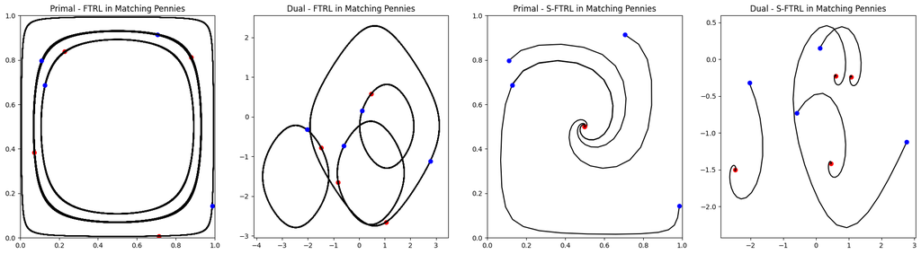

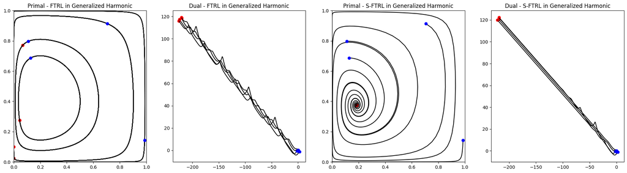

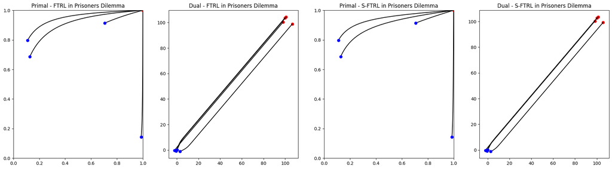

[output not shown]

[output not shown]

[output not shown]

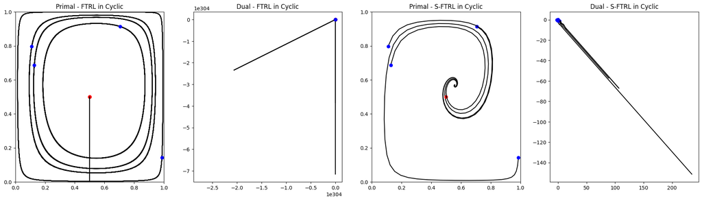

```python
# X and Y

LAM = -0.1

for i, s in enumerate(SFTRL_GAMES):

    fig = plt.figure(figsize = (24,6))

    ax1 = fig.add_subplot(1, 4, 1)
    ax2 = fig.add_subplot(1, 4, 2)
    ax3 = fig.add_subplot(1, 4, 3)
    ax4 = fig.add_subplot(1, 4, 4)

    for y0 in initial_dual_points:

        dual_points = odeint(s.sftrl_dyn, y0, time, args = (0,))
        plot_method(ax1, ax2, dual_points, s)
        ax1.set_title(f'Primal - FTRL in {s.name}')
        ax2.set_title(f'Dual - FTRL in {s.name}')

        corrected_dual_points = odeint(s.sftrl_dyn, y0, time, args = (LAM,))
        plot_method(ax3, ax4, corrected_dual_points, s)
        ax3.set_title(f'Primal - S-FTRL in {s.name}')
        ax4.set_title(f'Dual - S-FTRL in {s.name}')

    plt.show()

    #plt.xlim(0,1)
    #plt.ylim(0,1)
    #plt.legend(loc = 'best')
```

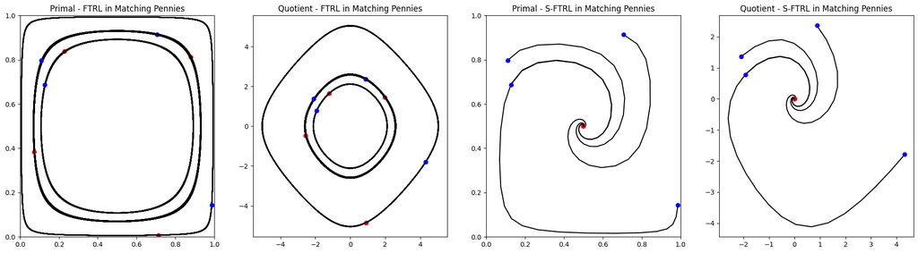

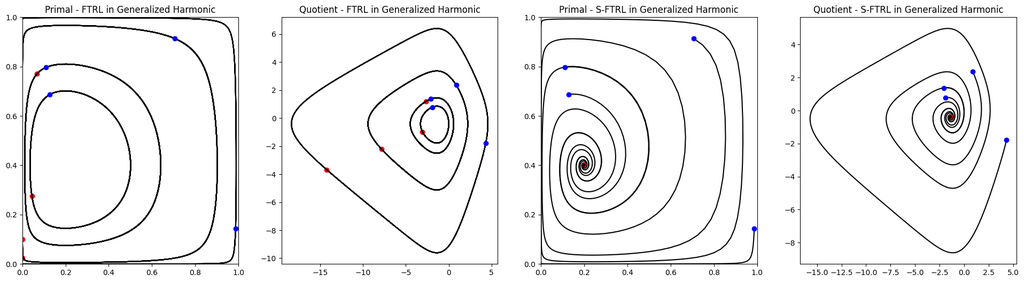

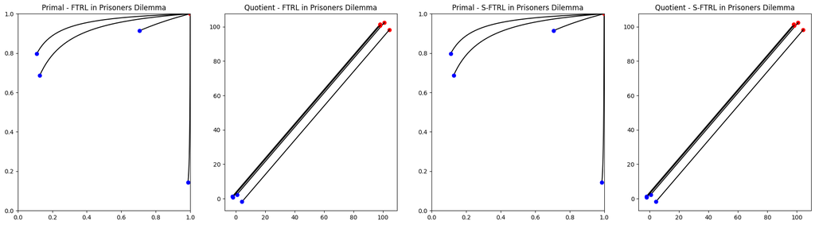

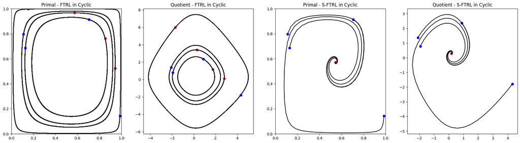

```python
# X and Z, full

LAM = -0.1

for i, s in enumerate(ZSFTRL_GAMES):

    fig = plt.figure(figsize = (24,6))

    ax1 = fig.add_subplot(1, 4, 1)
    ax2 = fig.add_subplot(1, 4, 2)
    ax3 = fig.add_subplot(1, 4, 3)
    ax4 = fig.add_subplot(1, 4, 4)

    for z0 in initial_quot_points:

        quot_points = odeint(s.sftrl_dyn, z0, time, args = (0,))
        plot_Zmethod(ax1, ax2, quot_points, s)
        ax1.set_title(f'Primal - FTRL in {s.name}')
        ax2.set_title(f'Quotient - FTRL in {s.name}')

        corrected_quot_points = odeint(s.sftrl_dyn, z0, time, args = (LAM,))
        plot_Zmethod(ax3, ax4, corrected_quot_points, s)
        ax3.set_title(f'Primal - S-FTRL in {s.name}')
        ax4.set_title(f'Quotient - S-FTRL in {s.name}')

    plt.show()

    #plt.xlim(0,1)
    #plt.ylim(0,1)
    #plt.legend(loc = 'best')
```

```python
eff_ZSFTRL_GAMES
```

```
[<symplecticFTRL.ZSFTRL at 0x1662f8dd0>,
 <symplecticFTRL.ZSFTRL at 0x166807a70>,
 <symplecticFTRL.ZSFTRL at 0x165339dc0>,
 <symplecticFTRL.ZSFTRL at 0x164686de0>]
```

```python
initial_eff_quot_points
```

```
[[4.327171084329156, -1.7905937066917648],
 [0.877838834314963, 2.363656805360328],
 [-2.091848180046225, 1.3670238615946002],
 [-1.9261912614747763, 0.7847539278768898]]
```

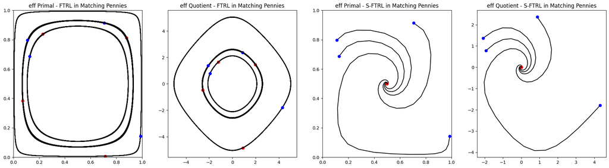

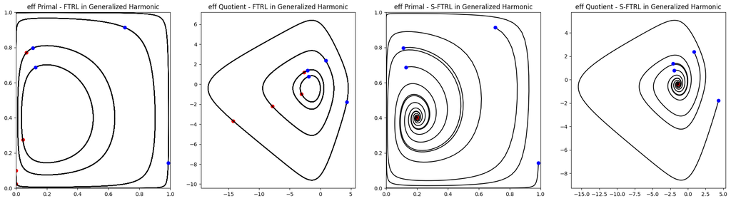

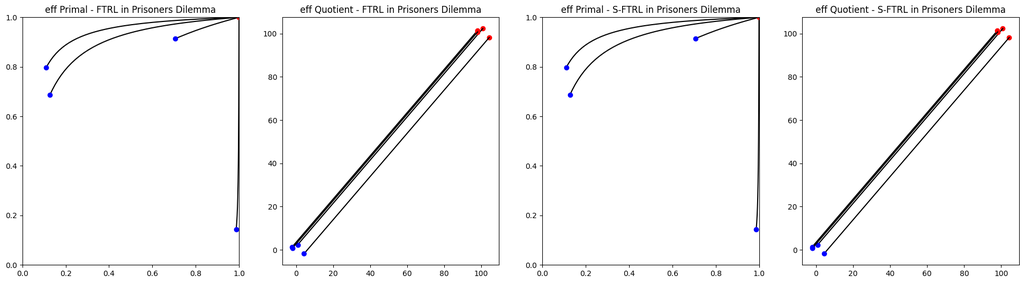

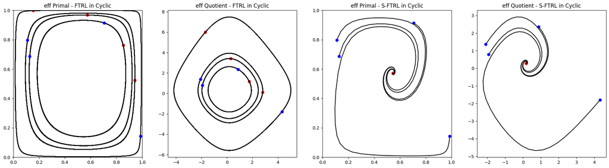

```python
# X and Z effective, ftrl vs symplectic ftrl geometric version

LAM = -0.1

for i, s in enumerate(eff_ZSFTRL_GAMES):

    fig = plt.figure(figsize = (24,6))

    ax1 = fig.add_subplot(1, 4, 1)
    ax2 = fig.add_subplot(1, 4, 2)
    ax3 = fig.add_subplot(1, 4, 3)
    ax4 = fig.add_subplot(1, 4, 4)

    for z0 in initial_eff_quot_points:

        eff_quot_points = odeint(s.geom_sftrl_dyn, z0, time, args = (0,))
        plot_effZmethod(ax1, ax2, eff_quot_points, s)
        ax1.set_title(f'eff Primal - FTRL in {s.name}')
        ax2.set_title(f'eff Quotient - FTRL in {s.name}')

        corrected_eff_quot_points = odeint(s.geom_sftrl_dyn, z0, time, args = (LAM,))
        plot_effZmethod(ax3, ax4, corrected_eff_quot_points, s)
        ax3.set_title(f'eff Primal - S-FTRL in {s.name}')
        ax4.set_title(f'eff Quotient - S-FTRL in {s.name}')

    plt.show()

    #plt.xlim(0,1)
    #plt.ylim(0,1)
    #plt.legend(loc = 'best')
```

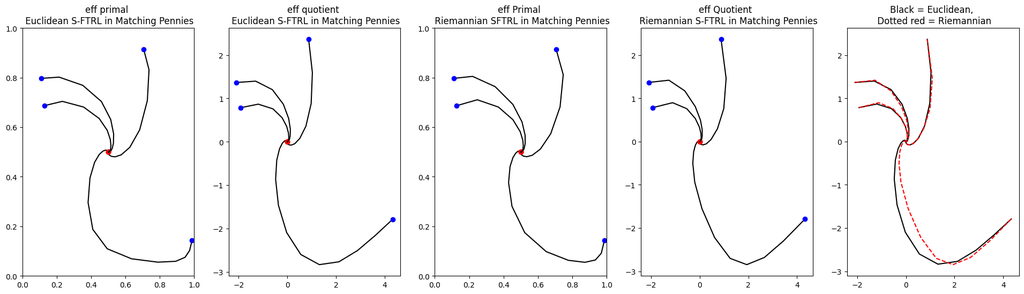

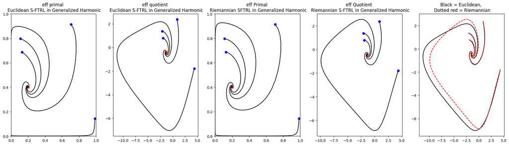

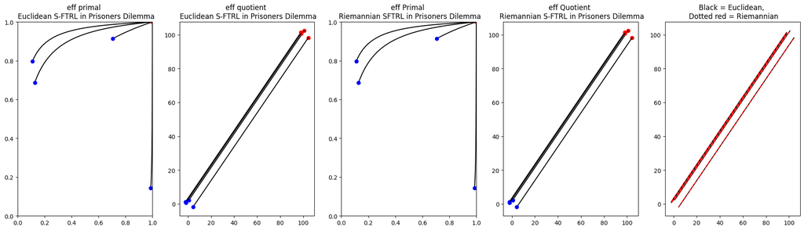

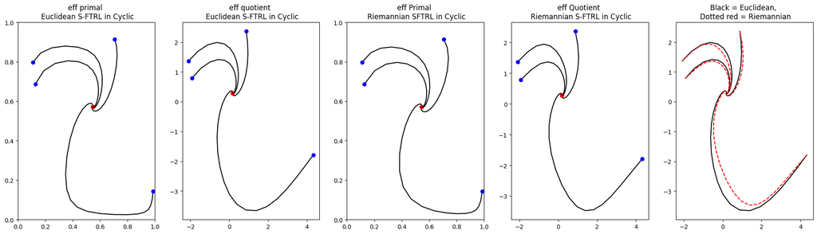

```python
# X and Z effective, symplectic vs geometric symplectic

LAM = -0.3

for i, s in enumerate(eff_ZSFTRL_GAMES):

    fig = plt.figure(figsize = (24,6))

    ax1 = fig.add_subplot(1, 5, 1)
    ax2 = fig.add_subplot(1, 5, 2)
    ax3 = fig.add_subplot(1, 5, 3)
    ax4 = fig.add_subplot(1, 5, 4)
    ax5 = fig.add_subplot(1, 5, 5)

    for z0 in initial_eff_quot_points:

        eu_eff_quot_points = odeint(s.sftrl_dyn, z0, time, args = (LAM,))
        plot_effZmethod(ax1, ax2, eu_eff_quot_points, s)
        ax1.set_title(f'eff primal \n Euclidean S-FTRL in {s.name}')
        ax2.set_title(f'eff quotient \n Euclidean S-FTRL in {s.name}')

        riem_eff_quot_points = odeint(s.geom_sftrl_dyn, z0, time, args = (LAM,))
        plot_effZmethod(ax3, ax4, riem_eff_quot_points, s)
        ax3.set_title(f'eff Primal \n Riemannian SFTRL in {s.name}')
        ax4.set_title(f'eff Quotient \n Riemannian S-FTRL in {s.name}')

        points_diff = eu_eff_quot_points - riem_eff_quot_points
        ax5.plot( *coords_points(eu_eff_quot_points), 'k')
        ax5.plot( *coords_points(riem_eff_quot_points), '--r')
        ax5.set_title('Black = Euclidean, \n Dotted red = Riemannian' )



    #plt.legend(loc = 'best')
    plt.show()

    #plt.xlim(0,1)
    #plt.ylim(0,1)
    #plt.legend(loc = 'best')
```

```python
test
```

```
<symplecticFTRL.ZSFTRL at 0x1662f8dd0>
```

## Quick and dirty

### $V \circ Q + \lambda \big[[d (Q^{\ast}V)](V \circ Q)\big]^{\sharp}$

```python
TEST = symplecticFTRL.SFTRL(MP.map_payfield, logit.Q, primal_vars, dual_vars, MP.name)
```

```python
TEST.sym_symplectic_1form
```

$\displaystyle \left[\begin{matrix}\frac{144 \left(e^{y_{0 0}} - e^{y_{0 1}}\right) e^{y_{0 0} + y_{0 1} + y_{1 0} + y_{1 1}}}{\left(e^{y_{0 0}} + e^{y_{0 1}}\right)^{3} \left(e^{y_{1 0}} + e^{y_{1 1}}\right)^{2}}\\\frac{144 \left(- e^{y_{0 0}} + e^{y_{0 1}}\right) e^{y_{0 0} + y_{0 1} + y_{1 0} + y_{1 1}}}{\left(e^{y_{0 0}} + e^{y_{0 1}}\right)^{3} \left(e^{y_{1 0}} + e^{y_{1 1}}\right)^{2}}\\\frac{144 \left(e^{y_{1 0}} - e^{y_{1 1}}\right) e^{y_{0 0} + y_{0 1} + y_{1 0} + y_{1 1}}}{\left(e^{y_{0 0}} + e^{y_{0 1}}\right)^{2} \left(e^{y_{1 0}} + e^{y_{1 1}}\right)^{3}}\\\frac{144 \left(- e^{y_{1 0}} + e^{y_{1 1}}\right) e^{y_{0 0} + y_{0 1} + y_{1 0} + y_{1 1}}}{\left(e^{y_{0 0}} + e^{y_{0 1}}\right)^{2} \left(e^{y_{1 0}} + e^{y_{1 1}}\right)^{3}}\end{matrix}\right]$

```python
TEST.sym_JQ
```

$\displaystyle \left[\begin{matrix}\frac{e^{y_{0 0}}}{e^{y_{0 0}} + e^{y_{0 1}}} - \frac{e^{2 y_{0 0}}}{\left(e^{y_{0 0}} + e^{y_{0 1}}\right)^{2}} & - \frac{e^{y_{0 0}} e^{y_{0 1}}}{\left(e^{y_{0 0}} + e^{y_{0 1}}\right)^{2}} & 0 & 0\\- \frac{e^{y_{0 0}} e^{y_{0 1}}}{\left(e^{y_{0 0}} + e^{y_{0 1}}\right)^{2}} & \frac{e^{y_{0 1}}}{e^{y_{0 0}} + e^{y_{0 1}}} - \frac{e^{2 y_{0 1}}}{\left(e^{y_{0 0}} + e^{y_{0 1}}\right)^{2}} & 0 & 0\\0 & 0 & \frac{e^{y_{1 0}}}{e^{y_{1 0}} + e^{y_{1 1}}} - \frac{e^{2 y_{1 0}}}{\left(e^{y_{1 0}} + e^{y_{1 1}}\right)^{2}} & - \frac{e^{y_{1 0}} e^{y_{1 1}}}{\left(e^{y_{1 0}} + e^{y_{1 1}}\right)^{2}}\\0 & 0 & - \frac{e^{y_{1 0}} e^{y_{1 1}}}{\left(e^{y_{1 0}} + e^{y_{1 1}}\right)^{2}} & \frac{e^{y_{1 1}}}{e^{y_{1 0}} + e^{y_{1 1}}} - \frac{e^{2 y_{1 1}}}{\left(e^{y_{1 0}} + e^{y_{1 1}}\right)^{2}}\end{matrix}\right]$

## Geometric version must be done in quotient space and in local coordinates to eliminate degeneracy

- $V \circ Q + \lambda [d(V \circ Q)](V \circ Q)$ works in $Y$, but it implies using Euclidean metric in dual space to identify 1-forms and vector fields
- it would be tempting to do $V \circ Q + \lambda \big[[d (Q^{\ast}V)](V \circ Q)\big]^{\sharp}$ to have geometric consistence in $Y$
- howevere these is no natural Riemannian metric in $Y$:
  - in $Y$, $h^{\ast}$ is in general only convex, not strictly convex, so it's hessian is in general not positive definite. In practice, the matrix $\text{Hess}h^{\ast} = \text{Jac}Q$ is **not invertible**, zero determinant (calculation done also on paper), so does not allow to define sharp operator on $Y$. This reflects the degeneracy / redundancy one introduces lifting to dual space
  - one could hope that degenercy can be quotiented away to $Z$ space. In this case though it's not clear which the metric should be, must to it on paper. The naive $\text{Jac} \hat{Q}$ is **not symmetric** if one retains all the coordinates (e.g $(0, z_1, 0, z_2)$ in 2x2 game
  - to get $\text{Jac}\hat{Q}$ both symmetric and positive-definite one must work in local coordinates, i.e. pull-back the vector field $Z$ to the hyperplane; equivalently, work from the very beginnin with effective payoff field.

```python
SFTRL_GAMES[0].sym_JQ
```

$\displaystyle \left[\begin{matrix}\frac{e^{y_{0 0}}}{e^{y_{0 0}} + e^{y_{0 1}}} - \frac{e^{2 y_{0 0}}}{\left(e^{y_{0 0}} + e^{y_{0 1}}\right)^{2}} & - \frac{e^{y_{0 0}} e^{y_{0 1}}}{\left(e^{y_{0 0}} + e^{y_{0 1}}\right)^{2}} & 0 & 0\\- \frac{e^{y_{0 0}} e^{y_{0 1}}}{\left(e^{y_{0 0}} + e^{y_{0 1}}\right)^{2}} & \frac{e^{y_{0 1}}}{e^{y_{0 0}} + e^{y_{0 1}}} - \frac{e^{2 y_{0 1}}}{\left(e^{y_{0 0}} + e^{y_{0 1}}\right)^{2}} & 0 & 0\\0 & 0 & \frac{e^{y_{1 0}}}{e^{y_{1 0}} + e^{y_{1 1}}} - \frac{e^{2 y_{1 0}}}{\left(e^{y_{1 0}} + e^{y_{1 1}}\right)^{2}} & - \frac{e^{y_{1 0}} e^{y_{1 1}}}{\left(e^{y_{1 0}} + e^{y_{1 1}}\right)^{2}}\\0 & 0 & - \frac{e^{y_{1 0}} e^{y_{1 1}}}{\left(e^{y_{1 0}} + e^{y_{1 1}}\right)^{2}} & \frac{e^{y_{1 1}}}{e^{y_{1 0}} + e^{y_{1 1}}} - \frac{e^{2 y_{1 1}}}{\left(e^{y_{1 0}} + e^{y_{1 1}}\right)^{2}}\end{matrix}\right]$

```python
SFTRL_GAMES[0].sym_JQ.det()
```

$\displaystyle 0$

```python
ZSFTRL_GAMES[0].sym_JQ
```

$\displaystyle \left[\begin{matrix}0 & - \frac{e^{z_{0 1}}}{\left(e^{z_{0 1}} + 1\right)^{2}} & 0 & 0\\0 & \frac{e^{z_{0 1}}}{e^{z_{0 1}} + 1} - \frac{e^{2 z_{0 1}}}{\left(e^{z_{0 1}} + 1\right)^{2}} & 0 & 0\\0 & 0 & 0 & - \frac{e^{z_{1 1}}}{\left(e^{z_{1 1}} + 1\right)^{2}}\\0 & 0 & 0 & \frac{e^{z_{1 1}}}{e^{z_{1 1}} + 1} - \frac{e^{2 z_{1 1}}}{\left(e^{z_{1 1}} + 1\right)^{2}}\end{matrix}\right]$

```python
ZSFTRL_GAMES[0].sym_JQ.det()
```

$\displaystyle 0$

## Positive definite (to check; cf Candogan code)

```python
eff_ZSFTRL_GAMES[0].sym_JQ
```

$\displaystyle \left[\begin{matrix}\frac{e^{z_{0 1}}}{e^{z_{0 1}} + 1} - \frac{e^{2 z_{0 1}}}{\left(e^{z_{0 1}} + 1\right)^{2}} & 0\\0 & \frac{e^{z_{1 1}}}{e^{z_{1 1}} + 1} - \frac{e^{2 z_{1 1}}}{\left(e^{z_{1 1}} + 1\right)^{2}}\end{matrix}\right]$

```python
eff_ZSFTRL_GAMES[0].sym_JQ.det()
```

$\displaystyle \frac{e^{2 z_{0 1}} e^{2 z_{1 1}} + e^{2 z_{0 1}} e^{z_{1 1}} + e^{z_{0 1}} e^{2 z_{1 1}} + e^{z_{0 1}} e^{z_{1 1}}}{e^{3 z_{0 1}} e^{3 z_{1 1}} + 3 e^{3 z_{0 1}} e^{2 z_{1 1}} + 3 e^{3 z_{0 1}} e^{z_{1 1}} + e^{3 z_{0 1}} + 3 e^{2 z_{0 1}} e^{3 z_{1 1}} + 9 e^{2 z_{0 1}} e^{2 z_{1 1}} + 9 e^{2 z_{0 1}} e^{z_{1 1}} + 3 e^{2 z_{0 1}} + 3 e^{z_{0 1}} e^{3 z_{1 1}} + 9 e^{z_{0 1}} e^{2 z_{1 1}} + 9 e^{z_{0 1}} e^{z_{1 1}} + 3 e^{z_{0 1}} + e^{3 z_{1 1}} + 3 e^{2 z_{1 1}} + 3 e^{z_{1 1}} + 1}$

## Geometric version

```python
MP_SFTRL.sym_JQ.det()
```

[output not shown]

```python
MP_SFTRL.sym_QpullV
```

[output not shown]

```python
MP_SFTRL.sym_d_QpullV
```

[output not shown]

## Careful about inversion of $JQ$ , must do in Z!

```python
MP_SFTRL.sftrl_dyn([1, 2, 3, 5], 0, 0.1)
```

[output not shown]

```python
MP_SFTRL.VQ( [1, 2, 3, 5] )
```

[output not shown]

## ODE

```python
time = np.linspace(0, 100, 10000)
```

```python
import random

num_orbits = 1

#initial_dual_points = [[random.uniform(-5, 5) for _ in range(4)] for n in range(num_orbits)]
initial_dual_points = [ [2,2.5,2.1,2.4] ]
```

```python
for s in SFTRL_GAMES:
    fig = plt.figure(figsize=(10, 5))
    ax1 = fig.add_subplot(1, 2, 1)
    ax2 = fig.add_subplot(1, 2, 2)
    for y0 in initial_dual_points:
        dual_points = odeint(s.sftrl_dyn, y0, time, args = (-0.0,))
        y00, y01, y10, y11 = coords_points(dual_points) # dual coords
        ax2.plot(y01[0], y11[0], 'bo', label = 'initial')
        ax2.plot(y01[-1], y11[-1], 'ro', label = 'final', ms = 8)
        ax2.plot(y01, y11, 'k')

        primal_points = [s.choice(*y) for y in dual_points]
        x00, x01, x10, x11 = coords_points(primal_points) # primal coords
        ax1.plot(x01, x11, 'k')
        ax1.plot(x01[0], x11[0], 'bo', label = 'initial')
        ax1.plot(x01[-1], x11[-1], 'ro', label = 'final', ms = 8)
    ax1.set_xlim(0,1)
    ax1.set_ylim(0,1)
    ax1.set_title('PRIMAL')
    ax2.set_title('DUAL')
    #plt.legend(loc = 'best')
    plt.title(f'Standard FTRL in {s.name} (finite games $\\to$ constrained setting & entropic regularizer)')
    plt.show()
```

[output not shown]

```python
for s in SFTRL_GAMES:
    fig = plt.figure(figsize=(10, 5))
    ax1 = fig.add_subplot(1, 2, 1)
    ax2 = fig.add_subplot(1, 2, 2)
    for y0 in initial_dual_points:
        dual_points = odeint(s.sftrl_dyn, y0, time, args = (-0.1,))  # <----------- symplectic correction
        y00, y01, y10, y11 = coords_points(dual_points) # dual coords
        ax2.plot(y01[0], y11[0], 'bo', label = 'initial')
        ax2.plot(y01[-1], y11[-1], 'ro', label = 'final', ms = 8)
        ax2.plot(y01, y11, 'k')

        primal_points = [s.choice(*y) for y in dual_points]
        x00, x01, x10, x11 = coords_points(primal_points) # primal coords
        ax1.plot(x01, x11, 'k')
        ax1.plot(x01[0], x11[0], 'bo', label = 'initial')
        ax1.plot(x01[-1], x11[-1], 'ro', label = 'final', ms = 8)

    ax1.set_xlim(0,1)
    ax1.set_ylim(0,1)
    ax1.set_title('PRIMAL')
    ax2.set_title('DUAL')
    plt.title(f'Symplectic FTRL in {s.name} (finite games $\\to$ constrained setting & entropic regularizer)\n\n')
    plt.show()
```

[output not shown]